# COMPSCIX 415.2 Homework 2

### Question 4: scatterplot of hwy vs cyl

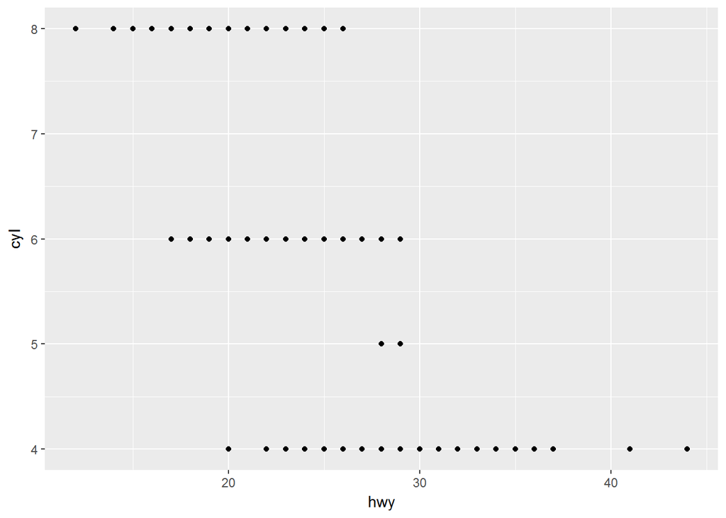

```r
g1 = g + geom_point(mapping = aes(x=hwy, y=cyl))
g1
```

### Question 4: scatterplot of class vs drv

This is not useful as both the vairables are categorical variables

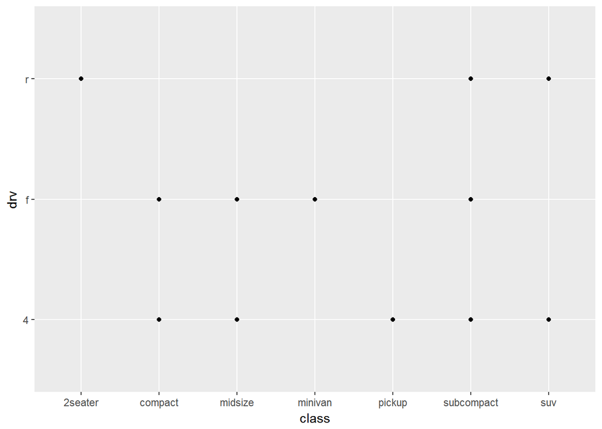

```r
g2 = g + geom_point(mapping = aes(x=class, y=drv))
g2
```

## Section 3.3.1

### Question 1: What’s wrong with this code, Why points are not blue?

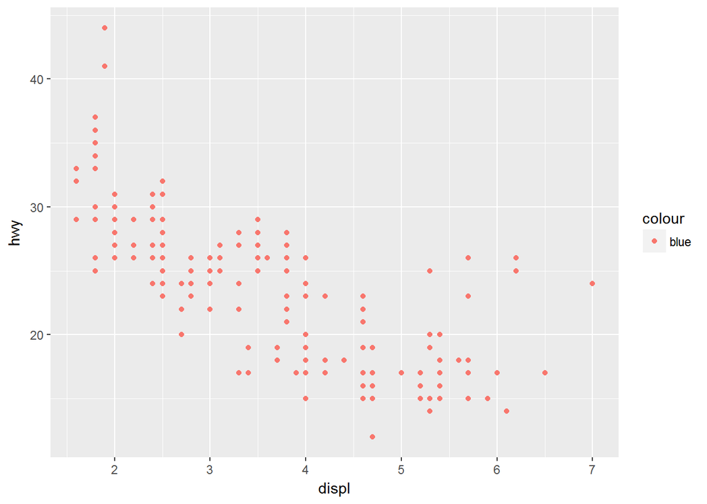

```r
g1 = g + geom_point(mapping = aes(x = displ, y = hwy, color = "blue"))
g1
```

Blue color needs to be a paramater to mapping functin and not aes function. This is correct code -

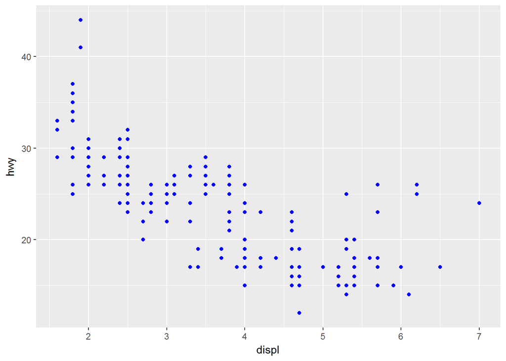

```r
g1 = g + geom_point(mapping = aes(x = displ, y = hwy), color = "blue")
g1
```

### Question 2: Categorical variables in mpg:

#### Categorical: Manufacturer, model, trans, drv, class

#### continous: displ, year, cyl, cty and hwy

you can see the column header when you run mpg

```r
mpg
```

```
## # A tibble: 234 x 11
##    manufacturer model    displ  year   cyl trans   drv     cty   hwy fl
##    <chr>        <chr>    <dbl> <int> <int> <chr>   <chr> <int> <int> <chr>
##  1 audi         a4         1.8  1999     4 auto(l~ f        18    29 p
##  2 audi         a4         1.8  1999     4 manual~ f        21    29 p
##  3 audi         a4         2    2008     4 manual~ f        20    31 p
##  4 audi         a4         2    2008     4 auto(a~ f        21    30 p
##  5 audi         a4         2.8  1999     6 auto(l~ f        16    26 p
##  6 audi         a4         2.8  1999     6 manual~ f        18    26 p
##  7 audi         a4         3.1  2008     6 auto(a~ f        18    27 p
##  8 audi         a4 quat~   1.8  1999     4 manual~ 4        18    26 p
##  9 audi         a4 quat~   1.8  1999     4 auto(l~ 4        16    25 p
## 10 audi         a4 quat~   2    2008     4 manual~ 4        20    28 p
## # ... with 224 more rows, and 1 more variable: class <chr>
```

### Question 3: Map continous variable to color, size and shape

#### color: Good

#### size: Good

#### shape: Error: continous variable can not be mapped to shape

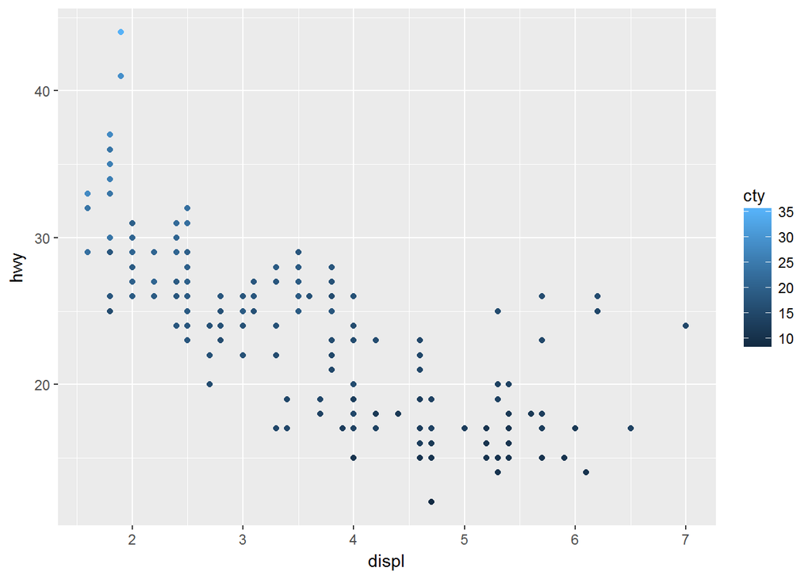

```r
ggplot(data = mpg) +
  geom_point(mapping = aes(x = displ, y = hwy, color = cty))
```

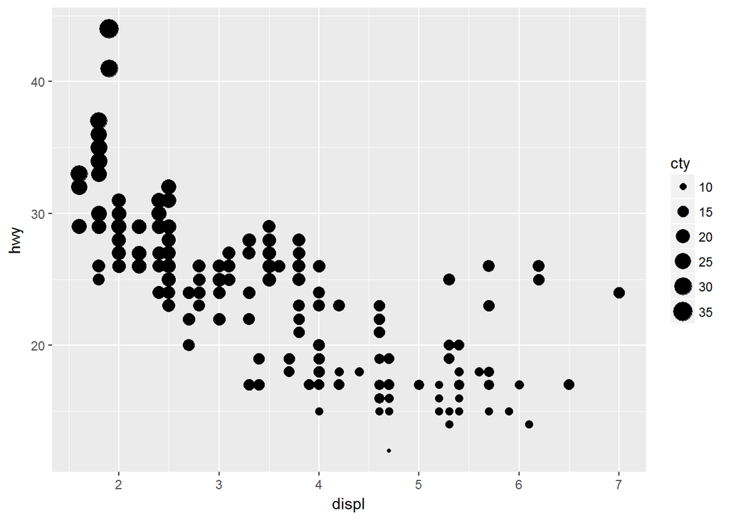

```r
ggplot(data = mpg) +
  geom_point(mapping = aes(x = displ, y = hwy, size = cty))
```

This code would throw an error. as cty is a continous variable: ggplot(data = mpg) + geom_point(mapping = aes(x = displ, y = hwy, shape = cty))

### Question 4: Map same variable to multiple aesthetics

#### Multiple aesthetics are implemented

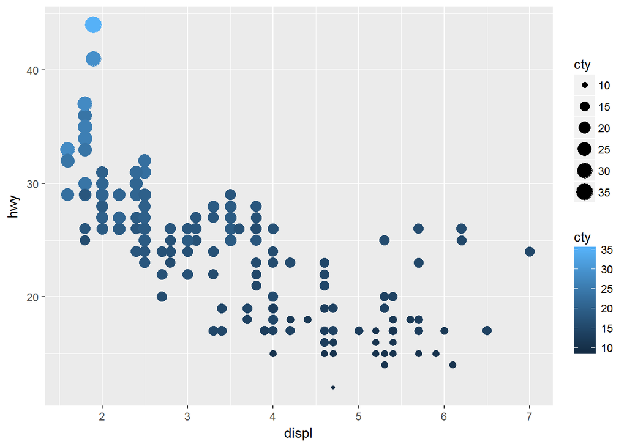

```r
ggplot(data = mpg) +
  geom_point(mapping = aes(x = displ, y = hwy, color = cty, size = cty))
```

### Question 5: stroke aesthetics makes boundary of shape more thicker or thinner.

#### works with most of the shapes

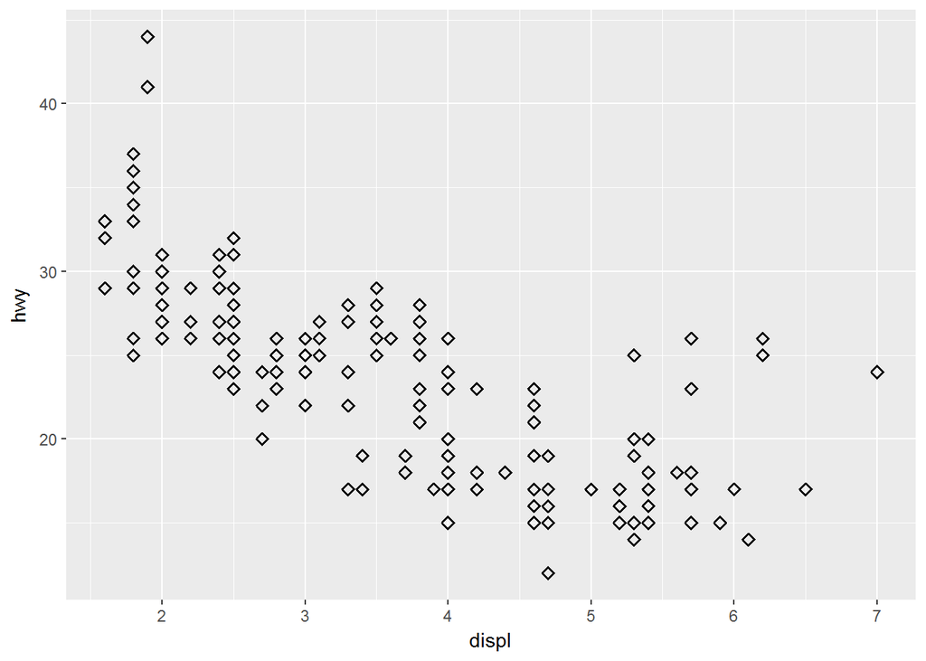

```r
ggplot(data = mpg) +
   geom_point(mapping = aes(x = displ, y = hwy), stroke = 1, shape = 5)
```

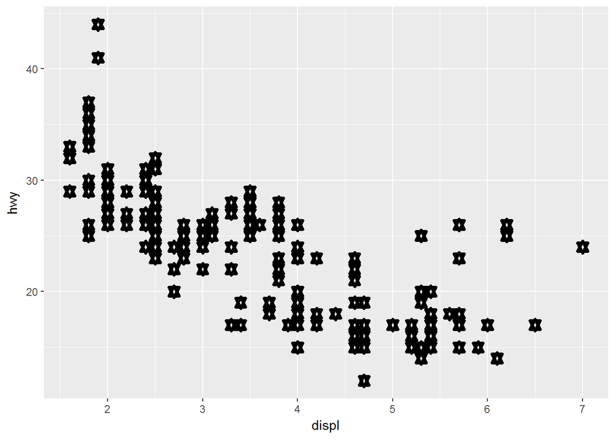

```r
ggplot(data = mpg) +
   geom_point(mapping = aes(x = displ, y = hwy), stroke = 2, shape = 11)
```

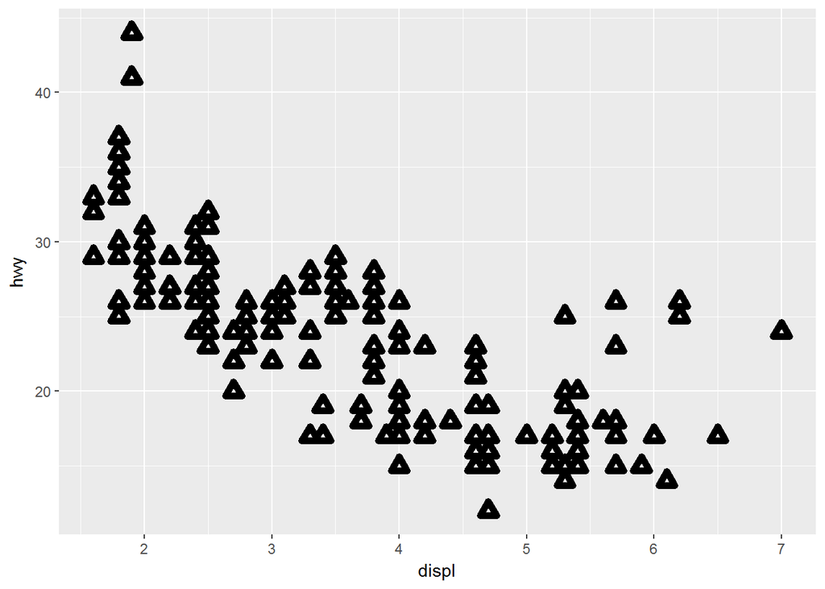

```r
ggplot(data = mpg) +
   geom_point(mapping = aes(x = displ, y = hwy), stroke = 3, shape = 24)
```

### Question 6: What happens if aes is other than a variable name

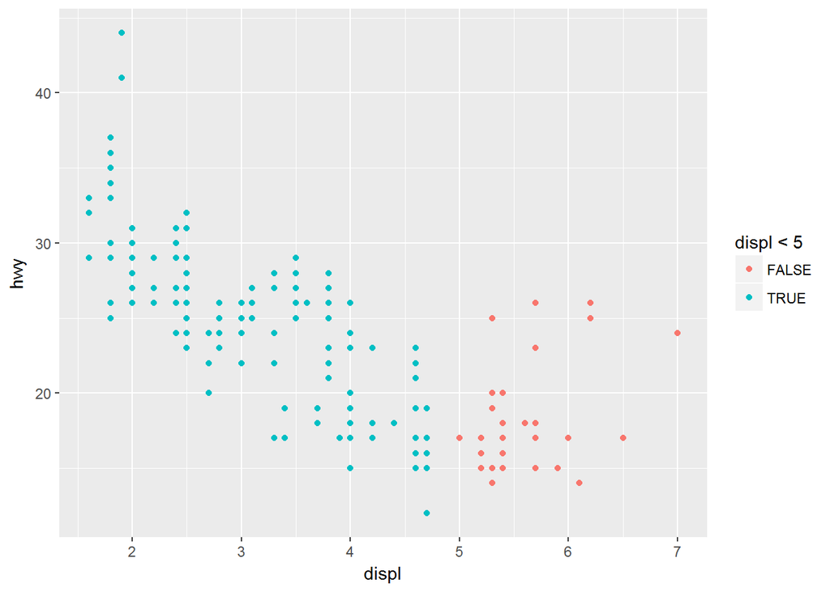

```r
ggplot(data = mpg) +
   geom_point(mapping = aes(x = displ, y = hwy, color = displ < 5))
```

#### Consider this as boolean and plot the data with 2 colors

## Section 3.5.1

### Question 4: What are the advantage and disadvantages of facets?

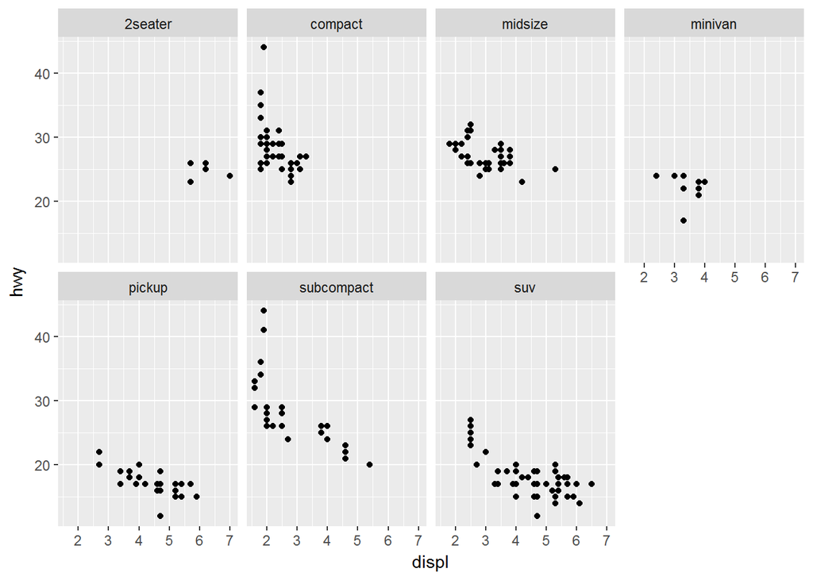

```r
ggplot(data = mpg) +
   geom_point(mapping = aes(x = displ, y = hwy)) +
  facet_wrap(~ class, nrow = 2)
```

## Section 3.6.1

### Question 1: Geom usage

#### line chart: geom_line

#### boxplot: geom_boxplot

#### histogram: geom_histogram

#### area: geom_area

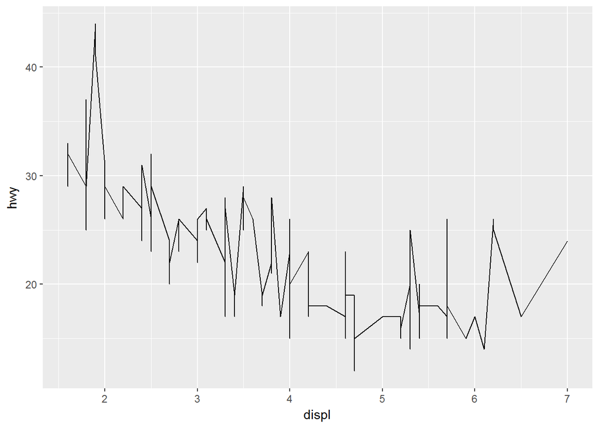

```r
ggplot(data = mpg) +
   geom_line(mapping = aes(x = displ, y = hwy))
```

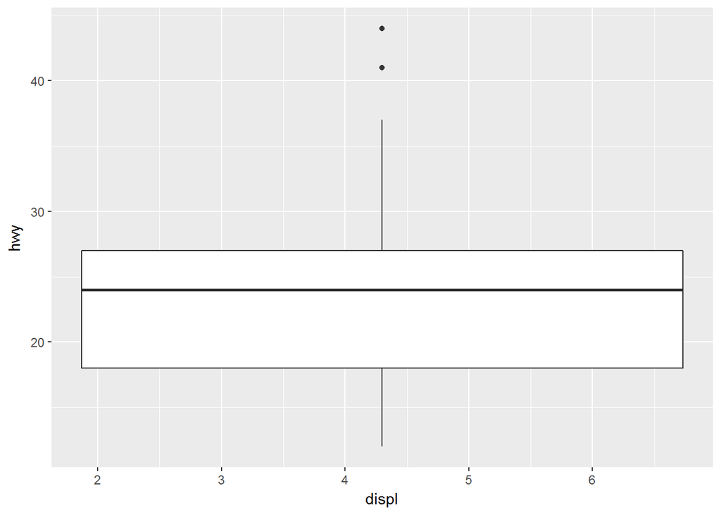

```r
ggplot(data = mpg) +
   geom_boxplot(mapping = aes(x = displ, y = hwy))
```

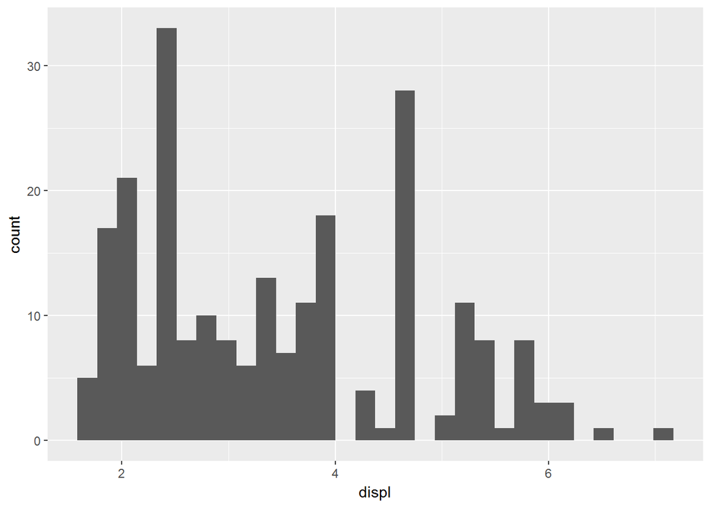

```r
ggplot(data = mpg) +
   geom_histogram(mapping = aes(x = displ))
```

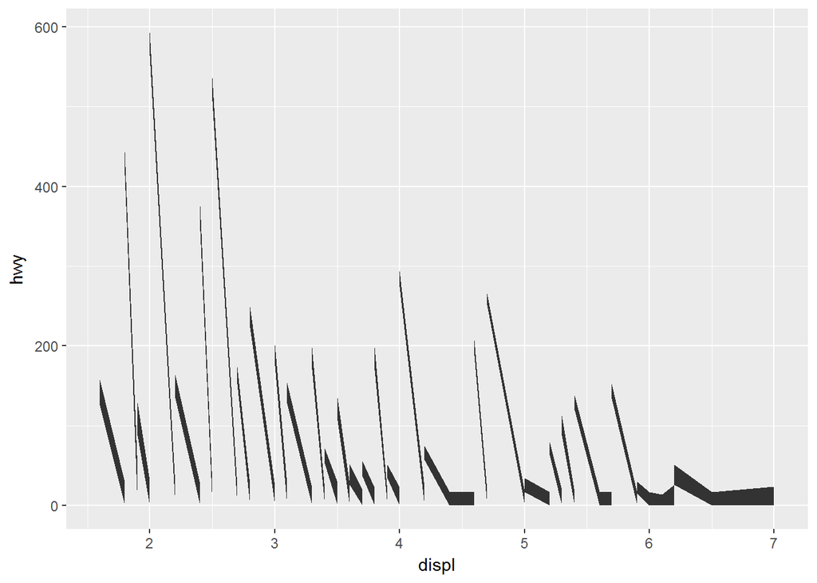

```r
ggplot(data = mpg) +
   geom_area(mapping = aes(x = displ, y = hwy))
```

### Question 2: Predict and run

#### Prediction: draw the scatter plot and smooth line chart with no confidence interval

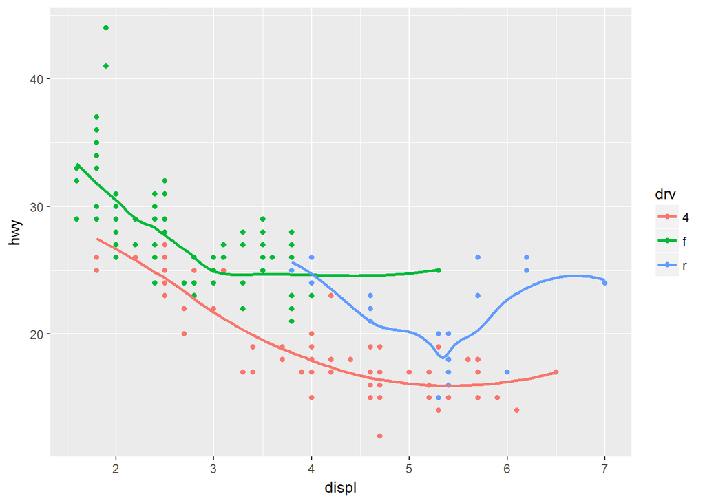

```r
ggplot(data = mpg, mapping = aes(x = displ, y = hwy, color = drv)) +
  geom_point() +
  geom_smooth(se = FALSE)
```

### Question 3: show.legend = FALSE

#### Does not show the legend on the right. By default, legends are shown whenever used.

#### Author used it to keep it consistent with other charts

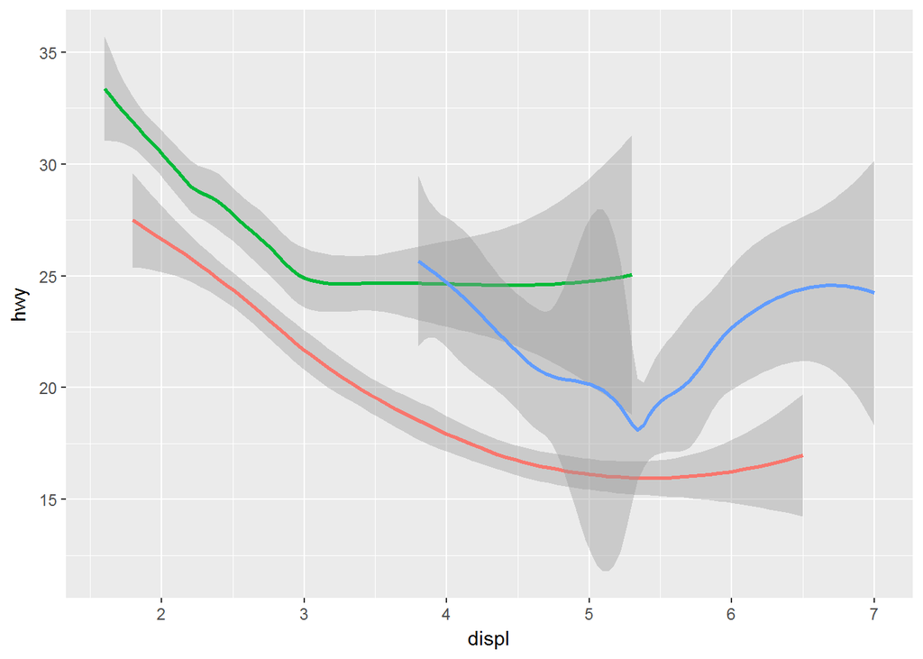

```r
ggplot(data = mpg) +
  geom_smooth(mapping = aes(x = displ, y = hwy, color = drv), show.legend = FALSE)
```

### Question 4: se argument

#### if se = FALSE, output does not show the considence interval. Buy default is is TRUE

### Question 5: Will these two graphs look different?

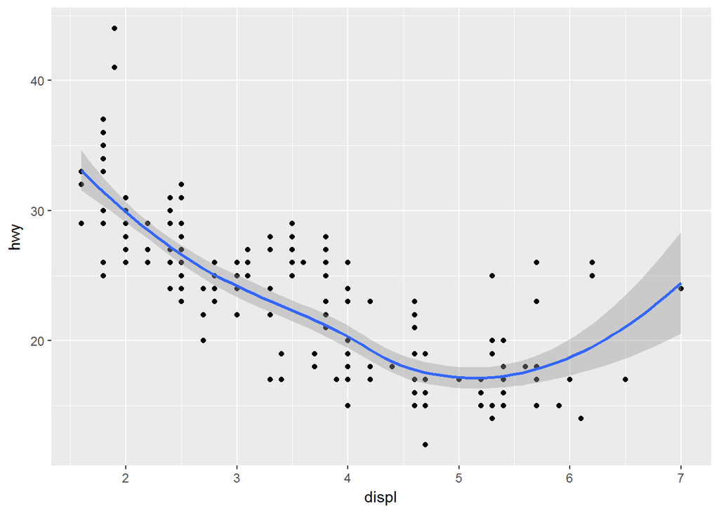

```r
ggplot(data = mpg, mapping = aes(x = displ, y = hwy)) +
  geom_point() +
  geom_smooth()
```

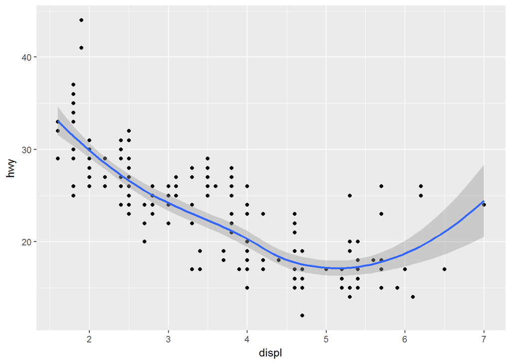

```r
ggplot() +
  geom_point(data = mpg, mapping = aes(x = displ, y = hwy)) +
  geom_smooth(data = mpg, mapping = aes(x = displ, y = hwy))
```

#### They look same because once parameters are provided to ggplot it is applicable for each layer added later

## Section 3.7.1

### Question 2: what does geom_col do? How is it diffeent than geom_bar?

#### geom_bar makes the height of the bar proportional to the number of cases in each group

#### geom_col is used if we want the heights of the bars to represent values in the data